# Lecture 25: Case Study: Approximate Bayesian Inference for Latent Gaussian Models by Using Integrated Nested Laplace Approximations

December 06, 2016

## Introduction - INLA

- Statistical inference for latent Gaussian Markov random field (GMRF), avoiding MCMC simulations
- Integrated nested Laplace approximation (INLA):
  - Fast Bayesian inference using accurate, multiple types of approximations to \(pr(\boldsymbol{\theta}\mid \boldsymbol{y})\) and marginal posterior densities for the latent variables \(\boldsymbol{x}\).
  - Can be used for model criticisms:
    1. Fast cross-validation
    2. Bayes factors and deviation information criterion (DIC) can be efficiently calculated for model comparisoins
- Software *inla* available from R; very easy to use

## Supported Models

- Hierarchical GMRF of the form: \[ \begin{aligned} y_j \mid \eta_j, \boldsymbol{\theta}_1 & \sim pr(y_j\mid \eta_j, \boldsymbol{\theta}_1), j\in J, \\ \eta_i & = Offset_i + \sum_{k=0}^{n_f-1}w_{ki}f_k(c_{ki})+\boldsymbol{z}_i'\boldsymbol{\beta}+\epsilon_i, i=0, \ldots, n_{\eta}-1. \end{aligned} \]
- \(J\subset \{0, 1,\ldots, n_{\eta}-1\}\), i.e., not all latent \(\boldsymbol{\eta}\) are observed through data \(\boldsymbol{y}\)
- \(pr(y_j\mid \eta_j, \boldsymbol{\theta}_1)\): likelihood of data; known link function
- \(\boldsymbol{\epsilon}=(\epsilon_0, \ldots, \epsilon_{n_\eta-1})'\mid \lambda_\eta \sim \mathcal{N}(\boldsymbol{0},\lambda_\eta\boldsymbol{I})\); \(\lambda_\eta\) denotes precision
- \(\boldsymbol{\eta}=(\eta_1, \eta_2, ...)\): a vector of predictors
- \(\boldsymbol{w}_k\): known weights for each observed data point

## Supported Models (continued)

- Hierarchical GMRF of the form: \[ \begin{aligned} y_j \mid \eta_j, \boldsymbol{\theta}_1 & \sim pr(y_j\mid \eta_j, \boldsymbol{\theta}_1), j\in J, \\ \eta_i & = Offset_i + \sum_{k=0}^{n_f-1}w_{ki}f_k(c_{ki})+\boldsymbol{z}_i'\boldsymbol{\beta}+\epsilon_i, i=0, \ldots, n_{\eta}-1. \end{aligned} \]
- \(f_{k}(c_{ki})\): effect of covariate \(k\) for observation \(i\); \(\{f_k\}_0^{n_f-1}\) nonlinear effect of continuous covariates, time trends and seasonal effects, two dimensional surfaces, iid random intercepts, slopes and spatial random effects. The unknown functions \(\boldsymbol{f}_k=(f_{0k},\ldots, f_{m_k-1,k})'\) are modelled as GMRF given some parameter \(\boldsymbol{\theta}_{f_k}\): \(\boldsymbol{f}_k\mid \boldsymbol{\theta}_{f_k}\sim \mathcal{N}(\boldsymbol{0}, \boldsymbol{Q}_k^{-1})\)
- \(\boldsymbol{z}_i\): a vector of \(n_\beta\) covariates assumed to have a linear effect; \(\boldsymbol{\beta}\): the corresponding vector of unknown parameters with independent zero-mean Gaussian prior with fixed precisions.

## Model

- \(\boldsymbol{x}=(\boldsymbol{\eta}', \boldsymbol{f}_0', \ldots, \boldsymbol{f}_{n_f-1}',\boldsymbol{\beta}')'\): full vector of latent variables; Dimension: \(n=n_\eta+\sum_{j=0}^{n_f-1}m_j+n_\beta\); note we parameterized \(\boldsymbol{x}\) by \(\boldsymbol{\eta}\) instead of \(\boldsymbol{\epsilon}\)
- All the elements of vector \(\boldsymbol{x}\) are defined as GMRFs: \[pr(\boldsymbol{x}\mid \boldsymbol{\theta}_2)= \prod_{i=0}^{n_\eta-1}pr(\eta_i\mid \boldsymbol{f}_0, \ldots, \boldsymbol{f}_{n_f-1},\boldsymbol{\beta}, \lambda_{\eta})\prod_{k=0}^{n_f-1}pr(\boldsymbol{f}_k\mid \kappa_{f_k})\prod_{m=0}^{n_\beta-1}pr(\beta_m),\] where \[ \eta_i\mid \boldsymbol{f}_0, \ldots, \boldsymbol{f}_{n_f-1},\boldsymbol{\beta} \sim \mathcal{N}\left(\sum_{k=0}^{n_f-1}f_k(c_{ki})+\boldsymbol{z}_i'\boldsymbol{\beta}, \lambda_\eta\right), \] and \(\boldsymbol{\theta}_2=\{\log\lambda_\eta, \boldsymbol{\theta}_{f_0}, \ldots, \boldsymbol{\theta}_{f_{n_f}-1}\}\) is a vector of unknown hyperparameters.

## Prior

- Specify priors on the hyperparameters: \(\boldsymbol{\theta}_2=\{\log\lambda_\eta, \boldsymbol{\theta}_{f_0}, \ldots, \boldsymbol{\theta}_{f_{n_f}-1}\}\)

## Core Technology

- Approximate the posterior density \(pr(\boldsymbol{\theta}\mid \boldsymbol{y})\) by a Gaussian approximation for \(\tilde{pr}(\boldsymbol{x},\boldsymbol{\theta} \mid \boldsymbol{y})\): \[pr(\boldsymbol{\theta}\mid \boldsymbol{y})\propto \frac{pr(\boldsymbol{\theta}, \boldsymbol{x}, \boldsymbol{y})}{pr(\boldsymbol{x},\boldsymbol{\theta} \mid \boldsymbol{y})}\bigg\rvert_{\boldsymbol{x}=\boldsymbol{x}^*(\boldsymbol{\theta})}\approx \frac{pr(\boldsymbol{\theta}, \boldsymbol{x}, \boldsymbol{y})}{\tilde{pr}(\boldsymbol{x},\boldsymbol{\theta} \mid \boldsymbol{y})}\bigg\rvert_{\boldsymbol{x}=\boldsymbol{x}^*(\boldsymbol{\theta})},\] where \(\boldsymbol{x}^*(\boldsymbol{\theta})=\arg\max_{\boldsymbol{x}}pr(\boldsymbol{x}\mid \boldsymbol{\theta}, \boldsymbol{y})\).
- Approximate evaluation of the posterior density for \(\boldsymbol{\theta}\) at any point
- Similar to Laplace approximation of a marginal posterior (Tierney and Kadane, 1986); approximation error \(\mathcal{O}(n_d^{-3/2})\)
- Key difference: the dimension of latent field \(\boldsymbol{x}\) is \(n\) (could be in thousands), could change with the number of observations \(n_d\), which is not theoretically treated in TK1986.

## Core Technology

- Can obtain marginal posterior for each \(\theta_k\) and \(x_j\) by numerical integration over \(\boldsymbol{\theta}\):
- \[pr(\theta_k \mid \boldsymbol{y}) \approx \int \tilde{pr} (\boldsymbol{\theta}\mid \boldsymbol{y}) d \boldsymbol{\theta}_{-k}\]
- \[pr(x_j \mid \boldsymbol{y}) \approx \int \tilde{pr}(x_j \mid \boldsymbol{\theta}, \boldsymbol{y})\tilde{pr}(\boldsymbol{\theta}\mid \boldsymbol{y}) d\boldsymbol{\theta}\]

## Comparing MCMC and INLA

- **MCMC**: Stochastic simulation of the posterior; Accurate if computing time is not a concern (rarely true)
- Components of latent field \(\boldsymbol{x}\) strongly dependent; \(\boldsymbol{\theta}\) and \(\boldsymbol{x}\) are also strongly dependent. Chains will mix painfully slow
- Usually requires blockwise proposal-and-rejection scheme (aka block MCMC)
- The Monte Carlo error decays at rate \(\mathcal{O}(N^{-1/2})\).
- Time: hours to days for some spatial models (see Rue et al, 2009)
- **INLA**: Deterministic; Using analytic approximations
- Suitable for latent GRM; Sparse precision matrix can speed up computations; Approximation bias found to be smaller than typical MCMC
- *Variational Bayes*: Also deterministic approximation; Iterative algorithm; Usually require exponential-family likelihood and priors on \(\boldsymbol{\theta}\)
- Time: seconds or minutes

## Examples

- Time series model: \(c_k=t\) for time, \(f_k\) for nonlinear trends or seasonal effects \[\eta_t = f_{trend}(t)+f_{seasonal}(t)+\boldsymbol{z}_t'\boldsymbol{\beta}\]
- Generalized additive models (GAM): \(pr(y_i\mid \eta_i,\boldsymbol{\theta}_l)\) belongs to an exponential family, \(c_k\) are univariate, continuous covariates and \(f_k\) are smooth functions

## Examples

- Generalized additive mixed models (GAMM) for longitudinal data
  - Individuals: \(i=0, \cdots, n_i-1\), observed at time points \(t_0, t_1, \ldots.\) A GAMM extends a GAM by introducing individual specific random effects: \[\eta_{it} = f_0(c_{it0})+\ldots+f_{n_f-1}(c_{it,n_f-1})+b_{oi}w_{it0}+\ldots+b_{n_b-1,i}w_{it,n_b-1},\] where \(\eta_{it}\) is the predictor for individual \(i\) at time \(t\), \(c_{itk}, k=0, \ldots, n_f-1, w_{itq}, q=0, \ldots, n_b-1\) are covariate values for individual \(i\) at time \(t\), and \(b_{0i}, \ldots, b_{n_b-1,i}\) is a vector of \(n_b\) individual specific random intercepts (if \(w_{itq}=1\)) or slopes.
  - Just define \(r=(i,t)\) and \(c_{kr}=c_{kit}\) for \(k=0, \ldots, n_f-1\) and \(c_{n_f-1+q,r}=w_{itq}\), \(f_{n_f-1+q}(c_{(n_f-1+q),r})=b_{qi}w_{kit}\) for \(q=0, \ldots, n_b\).

## Examples

- Geoadditive models (Kammann and Wand, 2003, JRSS-C): \[\eta_i = f_1(c_{0i})+\ldots+f_{n_f-1}(c_{n_f-1,i})+f_{spatial}(s_i)+\boldsymbol{z}_i'\boldsymbol{\beta},\] where \(s_i\) indicates the location of observation \(i\) and \(f_{spatial}\) is a spatially correlated effect.

## Examples

- ANOVA-type interaction model: For the effect of two continuous covariates \(w\) and \(v\): \[\eta_i = f_1(w_i)+f_2(v_i)+f_{1,2}(w_i,v_i)+\ldots,\] where \(f_1, f_2\) are the main effects and \(f_{1,2}\) is a two dimensional interaction surface. As a special case, we just define \(c_{1i}=w_i\), \(c_{2i}=v_i\) and \(c_{3i}=(w_i,v_i)\),
- Univariate stochastic volatility model
  - Time series models with Gaussian likelihood where the variance (not the mean) of the observed data is part of the latent GMRF model: \[y_i\mid \eta_i \sim \mathcal{N}(0,\exp(\eta_i)),\] and, for example, model the latent field \(\boldsymbol{\eta}\) as an autoregressive model of order \(1\).

## Bayesian for Spatial and Spatio-temporal Models (Blangiardo and Cameletti, 2015, Wiley)

[figure not shown]

## Gaussian Markov Random Fields (GMRF)

- GMRF: \(\boldsymbol{x}=(x_1, \ldots, x_n)'\) with Markov property that for some \(i\neq j\), \(x_i\perp x_j \mid \boldsymbol{x}_{-ij}\)
- Can be encoded by precision matrix \(\boldsymbol{Q}\): \(Q_{ij}=0\) if and only if \(x_i\perp x_j \mid \boldsymbol{x}_{-ij}\)
- Density function with mean vector \(\boldsymbol{\mu}\): \[pr(\boldsymbol{x}) = (2\pi)^{-n/2}|\boldsymbol{Q}|^{-1/2}\exp\{-\frac{1}{2}(\boldsymbol{x}-\boldsymbol{\mu})'\boldsymbol{Q}(\boldsymbol{x}-\boldsymbol{\mu})\}\]
- Most cases: \(\boldsymbol{Q}\) is sparse: only \(\mathcal{O}(n)\) of the \(n^2\) entries are nonzero
- Can handle extra linear constraints: \(\boldsymbol{A}\boldsymbol{x}=\boldsymbol{e}\) for a \(k\times n\) matrix \(\boldsymbol{A}\) of rank \(k\)
- *Computational note*: Simulation usually based on lower Cholesky decomposition \(\boldsymbol{Q}=\boldsymbol{L}\boldsymbol{L}'\), with \(\boldsymbol{L}\) preserving the sparseness in \(\boldsymbol{Q}\). *See Section 2.1 in Rue et al. (2009) for more details.*

## Gaussian Approximations

- Approximate density of the form \[pr(\boldsymbol{x})\propto \exp\left\{-\frac{1}{2}\boldsymbol{x}'\boldsymbol{Q}\boldsymbol{x}+\sum_{i\in \mathcal{I}}g_i(x_i)\right\},\] where \(g_i(x_i)=\log(pr(y_i\mid x_i, \boldsymbol{\theta}))\) in our setting.
- Gaussian approximation \(\tilde{pr}_G(\boldsymbol{x})\): obtained by matching the modal configuration and curvature at the mode (model could be computed by Newton-Raphson method)
- Let the mode be \(\boldsymbol{x}^*\), the precision matrix be \(\boldsymbol{Q}^*+diag(\boldsymbol{c}^*)\) (hint: use expansion to the second order - \(g_i(x_i)\approx g_i(\mu_i^{(0)})+b_ix_i-\frac{1}{2}c_ix_i^2\))
- *Property*: because the second summation does not involve \(x_i\) and \(x_j\) in one \(g()\), the resulting \(\boldsymbol{Q}^*\) preserves the Markov property in the original latent Gaussian model on \(\boldsymbol{x}\)

## INLA in Three Steps

- **Goal**: Compute posterior marginal \(pr(x_i\mid \boldsymbol{y})\), \(i=1, \ldots, n\).
- **Step I**: Laplace approximation to \(pr(\boldsymbol{\theta}\mid \boldsymbol{y})\); Will be used out to integrate out uncertainty about \(\boldsymbol{\theta}\)
- **Step II**: Simplified Laplace approximation to \(pr(\boldsymbol{x}_i\mid \boldsymbol{\theta},\boldsymbol{y})\) over selected \(\boldsymbol{\theta}\) values: \(\{\boldsymbol{\theta}_k\}\)
- **Step III**: Combines the previous two steps using numerical integration

## INLA - Step I: Approximate \(pr(\boldsymbol{\theta}\mid \boldsymbol{y})\)

- \(\boldsymbol{\theta}=(\theta_1, \ldots, \theta_m)\in \mathbb{R}^m\)
1. Locate the mode \(\boldsymbol{\theta}^*\) for \(\tilde{pr}(\boldsymbol{\theta}\mid \boldsymbol{y})\): optimize \(\log(\tilde{pr}(\boldsymbol{\theta}\mid \boldsymbol{y}))\) by quasi-Newton method; Compute the Hession matrix \(\boldsymbol{H}\) at \(\boldsymbol{\theta}=\boldsymbol{\theta}^*\)
2. Construct a representation for general \(\boldsymbol{\theta}\) values for exploration: \(\boldsymbol{\theta}=\boldsymbol{\theta}(\boldsymbol{z})=\boldsymbol{\theta}^*+\boldsymbol{V}\boldsymbol{\Lambda}^{1/2}\boldsymbol{z}\), where \(\boldsymbol{\Sigma}=\boldsymbol{H}^{-1}\) and \(\boldsymbol{\Sigma}\) has been spectrally decomposed as \(\boldsymbol{\Sigma}=\boldsymbol{V}\boldsymbol{\Lambda}\boldsymbol{V}'\)
3. Explore \(\log(\tilde{pr}(\boldsymbol{\theta}\mid \boldsymbol{y}))\) over a grid of \(\{\boldsymbol{\theta}_k\}\) by using the \(\boldsymbol{z}\)-parametrization. Need stepsize \(\delta_z\) in each \(\boldsymbol{z}\)-direction. For each grid points, assign weight \(\Delta_k\) (see next slide for an example with \(m=2\))
4. Can approximate \(pr(\theta_j\mid \boldsymbol{y})\) already!

## INLA - Step I-3

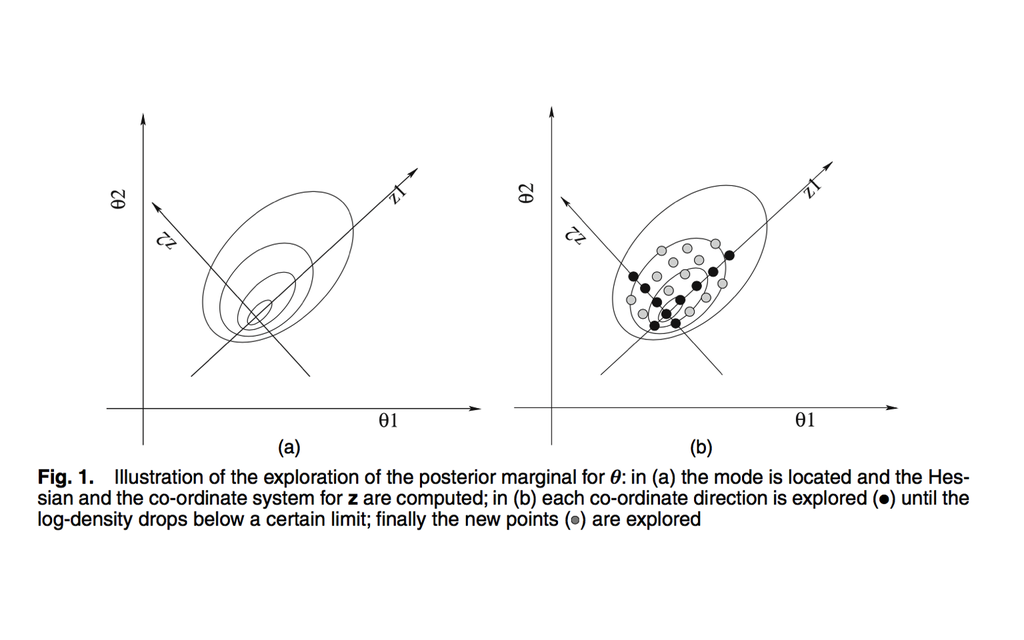

## INLA - Step II: Approximate \(pr(x_i \mid \boldsymbol{\theta}_k, \boldsymbol{y})\)

- Now we have a set of weighted points \(\{\boldsymbol{\theta}_k\}\), we obtain for each \(x_i\) the marginal posterior given each selected \(\boldsymbol{\theta}_k\) Three options:
1. Gaussian approximation: simplest and cheapest: \(\tilde{pr}_G(x_i\mid \boldsymbol{\theta}, \boldsymbol{y})\); There could be errors in the location or due to the lack of skewness
2. Laplace approximation \[\tilde{pr}_{LA}(x_i\mid \boldsymbol{\theta},\boldsymbol{y}) \propto \frac{pr(\boldsymbol{x},\boldsymbol{\theta}, \boldsymbol{y})}{\tilde{pr}_{GG}(\boldsymbol{x}_{-i} \mid x_i, \boldsymbol{\theta},\boldsymbol{y})}\bigg\rvert_{\boldsymbol{x}_{-i}=\boldsymbol{x}^*_{-i}(x_i, \theta)}\] Too expensive: recomputed \(\tilde{pr}_{GG}()\) at every \(x_i\). Has some fixes (see Section 3.2.3 of Rue et al. 2009)
3. **Simplified Laplace approximation**: Correct Gaussian approximation for location and skewness AND has computing time \(\mathcal{O}(n^2\log n)\exp(m)\).

## Summary

- Compute the posterior marginals for latent Gaussian Markov Random Field Models based on deterministic Laplace approximations
- Much faster than MCMC with small approximation biases
- Practically exact results by INLA over a randge of commonly used latent Gaussian models; Also has tools for assessing approximation errors to decide if they are non-neglegible (not discussed see Section 4 of Rue et al. 2009)
- Could be a basis for greater automation and parallel implementation; Core is the sparse matrix algorithms; Essentially no tunning.
- Disadvantage: computing time exponential of \(m\), the dimension of hyperparameters \(\boldsymbol{\theta}\)
- Could be used as a baseline model to explore smooth effects

## Extensions (Not Discussed)

- Approximate posterior marginals for a subset of \(\boldsymbol{x}_S\)
- Approximate marginal likelihood (e.g. for Bayes factor)
- Approximate predictive measures for model crticism and comparison
- Approximate Deviance Information Criteria (Spiegelhalter, 2002, Bayesian measure of model complexity and fit)